# BA-64060_Assignment 5

Inn Kyung Seo

2025-11-22

```r
cereals <- read.csv("C:/Users/beyou/Desktop/Cereals.csv", stringsAsFactors = FALSE)
head(cereals)
```

```
##                        name mfr type calories protein fat sodium fiber carbo
## 1                 100%_Bran   N    C       70       4   1    130  10.0   5.0
## 2         100%_Natural_Bran   Q    C      120       3   5     15   2.0   8.0
## 3                  All-Bran   K    C       70       4   1    260   9.0   7.0
## 4 All-Bran_with_Extra_Fiber   K    C       50       4   0    140  14.0   8.0
## 5            Almond_Delight   R    C      110       2   2    200   1.0  14.0
## 6   Apple_Cinnamon_Cheerios   G    C      110       2   2    180   1.5  10.5
##   sugars potass vitamins shelf weight cups   rating
## 1      6    280       25     3      1 0.33 68.40297
## 2      8    135        0     3      1 1.00 33.98368
## 3      5    320       25     3      1 0.33 59.42551
## 4      0    330       25     3      1 0.50 93.70491
## 5      8     NA       25     3      1 0.75 34.38484
## 6     10     70       25     1      1 0.75 29.50954
```

```r
cereals_clean <- na.omit(cereals)
dim(cereals_clean)
```

```
## [1] 74 16
```

```r
library(dplyr)
cereals_num <- cereals_clean %>%
  select(where(is.numeric))

str(cereals_num)
```

```
## 'data.frame':    74 obs. of  13 variables:
##  $ calories: int  70 120 70 50 110 110 130 90 90 120 ...
##  $ protein : int  4 3 4 4 2 2 3 2 3 1 ...
##  $ fat     : int  1 5 1 0 2 0 2 1 0 2 ...
##  $ sodium  : int  130 15 260 140 180 125 210 200 210 220 ...
##  $ fiber   : num  10 2 9 14 1.5 1 2 4 5 0 ...
##  $ carbo   : num  5 8 7 8 10.5 11 18 15 13 12 ...
##  $ sugars  : int  6 8 5 0 10 14 8 6 5 12 ...
##  $ potass  : int  280 135 320 330 70 30 100 125 190 35 ...
##  $ vitamins: int  25 0 25 25 25 25 25 25 25 25 ...
##  $ shelf   : int  3 3 3 3 1 2 3 1 3 2 ...
##  $ weight  : num  1 1 1 1 1 1 1.33 1 1 1 ...
##  $ cups    : num  0.33 1 0.33 0.5 0.75 1 0.75 0.67 0.67 0.75 ...
##  $ rating  : num  68.4 34 59.4 93.7 29.5 ...
##  - attr(*, "na.action")= 'omit' Named int [1:3] 5 21 58
##   ..- attr(*, "names")= chr [1:3] "5" "21" "58"
```

```r
cereals_scaled <- scale(cereals_num)

head(cereals_scaled)
```

```
##     calories    protein        fat     sodium       fiber      carbo     sugars
## 1 -1.8659155  1.3817478  0.0000000 -0.3910227  3.22866747 -2.5001396 -0.2542051
## 2  0.6537514  0.4522084  3.9728810 -1.7804186 -0.07249167 -1.7292632  0.2046041
## 3 -1.8659155  1.3817478  0.0000000  1.1795987  2.81602258 -1.9862220 -0.4836096
## 4 -2.8737823  1.3817478 -0.9932203 -0.2702057  4.87924705 -1.7292632 -1.6306324
## 6  0.1498180 -0.4773310  0.9932203  0.2130625 -0.27881412 -1.0868662  0.6634132
## 7  0.1498180 -0.4773310 -0.9932203 -0.4514312 -0.48513656 -0.9583868  1.5810314
##       potass   vitamins      shelf     weight       cups     rating
## 1  2.5605229 -0.1818422  0.9419715 -0.2008324 -2.0856582  1.8549038
## 2  0.5147738 -1.3032024  0.9419715 -0.2008324  0.7567534 -0.5977113
## 3  3.1248675 -0.1818422  0.9419715 -0.2008324 -2.0856582  1.2151965
## 4  3.2659536 -0.1818422  0.9419715 -0.2008324 -1.3644493  3.6578436
## 6 -0.4022862 -0.1818422 -1.4616799 -0.2008324 -0.3038480 -0.9165248
## 7 -0.9666308 -0.1818422 -0.2598542 -0.2008324  0.7567534 -0.6553998
```

```r
library(cluster)

methods <- c("single", "complete", "average", "ward")

agnes_list <- lapply(methods, function(m) {
  agnes(cereals_scaled, method = m)
})
names(agnes_list) <- methods

sapply(agnes_list, function(x) x$ac)
```

```
##    single  complete   average      ward
## 0.6067859 0.8353712 0.7766075 0.9046042
```

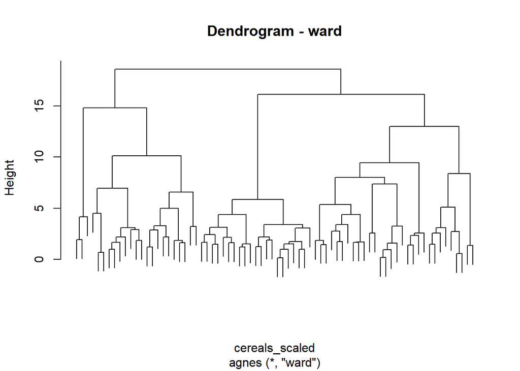

```r
best_method <- "ward"
best_agnes <- agnes_list[[best_method]]

hc_best <- as.hclust(best_agnes)

plot(hc_best, labels = FALSE, main = paste("Dendrogram -", best_method))
```

```r
library(cluster)

sil_width <- c()

for (k in 2:10) {
  clusters_k <- cutree(hc_best, k = k)
  sil <- silhouette(clusters_k, dist(cereals_scaled))
  sil_width[k] <- mean(sil[, "sil_width"])
}

sil_width
```

```
##  [1]        NA 0.2008371 0.1887617 0.2242571 0.2580063 0.2611020 0.2806771
##  [8] 0.2991423 0.2964169 0.3138485
```

```r
which.max(sil_width)
```

```
## [1] 10
```

```r
k_best <- 10
clusters <- cutree(hc_best, k = k_best)
table(clusters)
```

```
## clusters
##  1  2  3  4  5  6  7  8  9 10
##  3 10 21 10 10  2  5  7  4  2
```

```r
cereal_cluster_profile <- cereals_clean %>%
  mutate(cluster = clusters) %>%
  group_by(cluster) %>%
  summarise(
    n = n(),
    mean_calories = mean(calories, na.rm = TRUE),
    mean_sugar    = mean(sugars,   na.rm = TRUE),
    mean_fiber    = mean(fiber,    na.rm = TRUE),
    mean_protein  = mean(protein,  na.rm = TRUE),
    mean_fat      = mean(fat,      na.rm = TRUE),
    mean_sodium   = mean(sodium,   na.rm = TRUE),
    mean_rating   = mean(rating,   na.rm = TRUE)
  )

cereal_cluster_profile
```

```
## # A tibble: 10 × 9
##    cluster     n mean_calories mean_sugar mean_fiber mean_protein mean_fat
##      <int> <int>         <dbl>      <dbl>      <dbl>        <dbl>    <dbl>
##  1       1     3          63.3       3.67     11             4       0.667
##  2       2    10         116         7.8       2.55          3.3     2.5
##  3       3    21         111.       11.3       0.571         1.52    1
##  4       4    10         132        10.9       3.65          3       1.4
##  5       5    10         100         3.8       2.6           2.6     0.5
##  6       6     2         110         2         1.5           6       1
##  7       7     5         108         2.6       0.2           1.8     0.2
##  8       8     7          91.4       3         2.57          2.71    0.143
##  9       9     4         105         3.75      1.25          2.5     0.75
## 10      10     2          50         0         0.5           1.5     0
## # ℹ 2 more variables: mean_sodium <dbl>, mean_rating <dbl>
```

```r
healthy_cluster_id <- 1

healthy_cereals <- cereals_clean %>%
  mutate(cluster = clusters) %>%
  filter(cluster == healthy_cluster_id) %>%
  select(name, calories, sugars, fiber, protein, fat, sodium, rating)

healthy_cereals
```

```
##                        name calories sugars fiber protein fat sodium   rating
## 1                 100%_Bran       70      6    10       4   1    130 68.40297
## 2                  All-Bran       70      5     9       4   1    260 59.42551
## 3 All-Bran_with_Extra_Fiber       50      0    14       4   0    140 93.70491
```

```r
set.seed(123)

n <- nrow(cereals_scaled)
idx_A <- sample(1:n, size = round(0.5 * n))
idx_B <- setdiff(1:n, idx_A)

A_scaled <- cereals_scaled[idx_A, ]
B_scaled <- cereals_scaled[idx_B, ]
```

```r
agnes_A <- agnes(A_scaled, method = best_method)
hc_A <- as.hclust(agnes_A)

clusters_A <- cutree(hc_A, k = k_best)
```

```r
A_df <- as.data.frame(A_scaled)
A_df$cluster <- clusters_A
```

```r
colnames(A_df)
```

```
##  [1] "calories" "protein"  "fat"      "sodium"   "fiber"    "carbo"
##  [7] "sugars"   "potass"   "vitamins" "shelf"    "weight"   "cups"
## [13] "rating"   "cluster"
```

```r
centroids <- A_df %>%
  group_by(cluster) %>%
  summarise(across(where(is.numeric), mean)) %>%
  arrange(cluster)
```

```r
centroids_mat <- as.matrix(centroids[,-1])
```

```r
assign_cluster_B <- function(x, centers) {
  dists <- apply(centers, 1, function(c) sum((x - c)^2))
  which.min(dists)
}

pred_B <- apply(B_scaled, 1, assign_cluster_B, centers = centroids_mat)
```

```r
true_B <- clusters[idx_B]

table(pred_B, true_B)
```

```
##       true_B
## pred_B 1 2 3 4 5 6 7 8 9 10
##     1  3 0 0 0 2 0 0 1 0  0
##     2  0 0 0 1 0 0 0 0 0  0
##     3  0 0 8 0 0 0 0 0 0  0
##     4  0 0 0 0 1 0 3 0 3  0
##     5  0 0 0 0 0 0 0 2 0  2
##     6  0 4 0 1 0 0 0 0 0  0
##     7  0 1 0 0 0 0 0 0 0  0
##     8  0 0 2 0 1 0 0 0 0  0
##     9  0 0 0 0 0 1 0 0 0  0
##     10 0 0 0 1 0 0 0 0 0  0
```

```r
library(mclust)
adjustedRandIndex(pred_B, true_B)
```

```
## [1] 0.531276
```

**Conclusion**

1. Stability Evaluation

To evaluate how stable the clustering solution is, the dataset was randomly split into two subsets, A and B. Subset A was used to generate the hierarchical clustering model (Ward linkage, k = 10), and cluster centroids were computed based on A. Then, each record in subset B was assigned to the nearest centroid from A, and these predicted cluster labels were compared with the cluster assignments obtained from the full dataset. The resulting Adjusted Rand Index (ARI) was 0.53, indicating a moderate level of agreement between the two clusterings. Although the clusters are not perfectly consistent across the partitions, the ARI value suggests that the overall clustering structure is reasonably stable. This means that the clusters are reliably capturing underlying patterns in the nutritional data, despite natural variability and the high dimensionality of the cereal attributes. Therefore, the clustering solution can be considered sufficiently robust for interpretation and for practical decision-making, such as identifying healthier cereal groups.

2. Should the Data Be Normalized?

Yes, the data should be normalized before performing hierarchical clustering. This is because the Euclidean distance measure used in the clustering algorithm is highly sensitive to differences in scale. In this dataset, nutritional variables such as calories, sugar, sodium, and fiber are recorded in different units and have different numerical ranges. If the data were not normalized, variables with large ranges would disproportionately influence the distance calculations, overpowering variables with smaller ranges (such as fat or fiber). By standardizing all numeric variables to have mean 0 and standard deviation 1, each attribute contributes equally to the clustering process. Normalization ensures that the resulting clusters represent genuine patterns in cereal nutrition rather than artifacts caused by unequal scaling.Therefore, normalization is essential for obtaining meaningful, balanced, and interpretable clusters in this analysis.